[figure not shown]

# Limits of Agreement

## What is a Limit of Agreement?

Simply put, calculating the limit of agreement (LoA) between two systems equates to estimating the expected difference and the predictive confidence band for this estimate. The estimated difference between the two systems is often referred to as the bias, whereas the confidence interval of prediction based on the estimate is what is actually termed the LoA. While many options exist for comparing systems, LoA’s are intuitive as they return the expected difference in actual measurement units which is practically meaningful. Various approaches can be taken to estimate LoA’s, however, due to the way validation data is often collected with participants contributing multiple trials, we take a mixed model approach to the problem in this tutorial.

## Discrete vs Functional Validation

The choice to perform discrete or functional validation of a system will depend on the intended purpose for collecting data. Discrete validation may be used to check the validity of how a system captures a distinct feature of a movement, e.g. peak knee flexion. This is appropriate when **ONLY** the discrete metric is of interest in downstream analysis. Examples of this may be comparing two force plate systems for calculating jump height from a counter movement jump or peak force production from an isometric mid-thigh pull. Functional refers to the fact that the data collected is assumed to be an observation of a continuous process and thus observations are treated as a “function” rather than as a discretised set of observations over time. Functional validation then provides the estimated bias and LoA across the whole observed movement rather than just one specific point. If data from the system being compared is intended to be used in forms of analysis that investigate movement in a holistic way such as statistical parametric mapping (SPM) or other forms of functional data analysis (FDA) we recommend taking a functional approach to validation.

# Case Study: Gait

In this case study we demonstrate both functional and discrete validation on a synthetic data set containing repeated observations of sagittal knee flexion from 20 participants during walking. Each for each trial there is an observation from the reference system (System 1) and the test system (System 2). The data set is generated from the `gait` data attached to the `fda` `R` package. We simulated 100 observations in total then created a copy of these observations which system specific, participant specific, and miscellaneous noise has been added to. As a resource we provide the code (including for the data generation) as a resource for future use at https://github.com/arlohook/AISValidation.git

## Data

To begin with we visually inspect the data with colours indicative of participant.

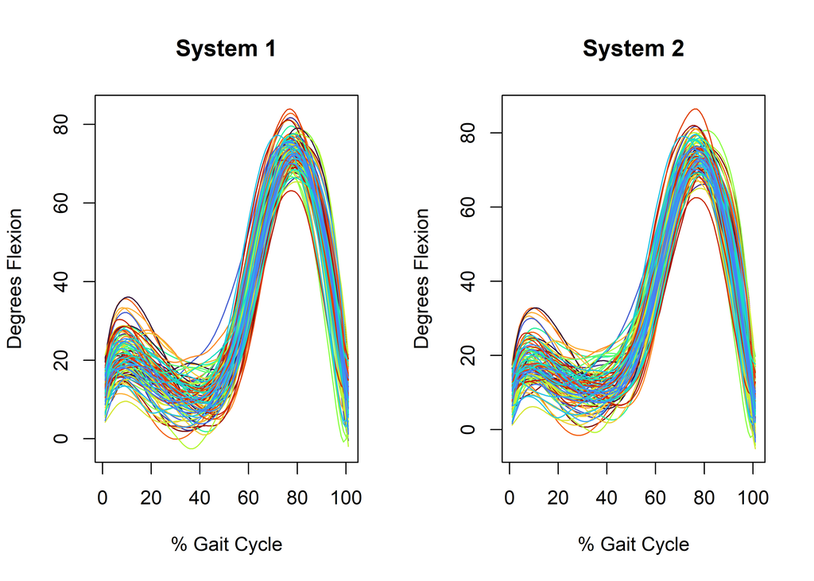

## Discrete Limit of Agreement

To demonstrate the estimation of a discrtete limit of agreement we will focus on the peak knee flexion value recorded by each system. SInce we have repeated measurements from each participant we will use a mixed model with a random intercept for each participant to account for this feature in the data. The process is performed as follows:

1. Calculate the peak knee flexion for each trial from each system
2. Calculate the trial level difference between systems as System 1 $-$ System 2
3. Estimate the expected value of this difference via a mixed model (this will be the fixed intercept estimate)
4. Estimate the error variance of this estimator and construct a 95% confidence interval which is the LoA
5. Visualise the results

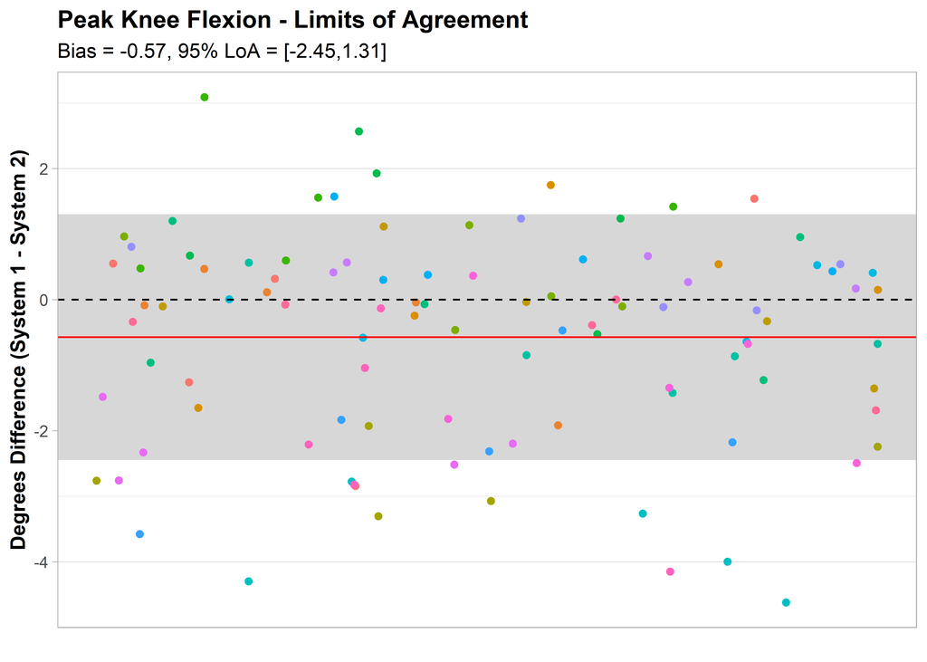

Based on this result there is very little difference between the two systems in their peak knee flexion angles. We note that this does not take into account the timing of this value only the magnitude of the derived measurement.

## Functional Limit of Agreement

Next we demonstrate functional LoA on the same data. This follows the same process as discrete LoA except we model the difference over time rather than at one discrete point. One key difference however is in the construction of the LoA band. We estimate a “simultaneous” band that aims to give 95% coverage across the whole domain, i.e. gait cycle, rather than the “point wise” estimate. This is because the point wise estimate is generally shrunken due to the correlation structure of functional data and doesn’t provide the desired level of coverage i.e. 95%. The simultaneous band is constructed via a bootstrapping procedure with re-sampling at the participant level because of the multi-level structure of the data.

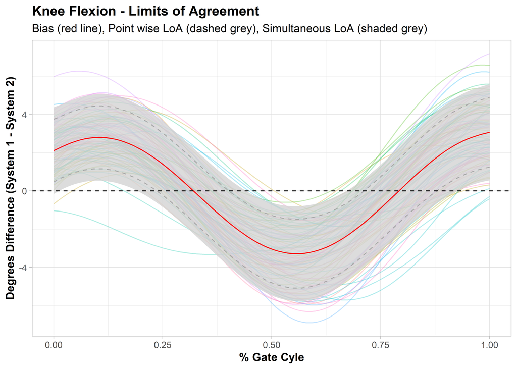